# **Computer Vision Project : Pneumonia Detecion Challenge**

## **Problem Statements**

### **Context**

Pneumonia is a serious respiratory infection characterized by inflammation of the lungs, which can be life-threatening if not detected and treated early. Traditionally, diagnosis is performed by radiologists through careful examination of chest X-ray images. However, manual diagnosis is time-consuming, subjective, and prone to inter-observer variability, especially when there are a large number of cases to evaluate.

With the advancement of computer vision and deep learning techniques, automated analysis of chest radiographs has become feasible. In this project, the objective is to build an algorithm that can automatically detect pneumonia in chest X-rays by identifying lung opacities — the visual signals of pneumonia. The system must not only predict the presence of pneumonia but also provide bounding boxes around the affected lung regions, thereby assisting radiologists with faster and more accurate diagnosis.

This problem falls within the healthcare domain and is a classic computer vision detection task, requiring both classification (pneumonia vs. non-pneumonia) and localization (drawing bounding boxes).

**Locate lung opacities on chest radiographs**

### **Data Description**

The dataset is derived from the RSNA Pneumonia Detection Challenge and is provided in DICOM format, the standard for medical imaging. It consists of chest radiographs and associated metadata for both training and testing.

**Files provided:**

- stage_2_train_images.zip – Training chest X-ray images in DICOM format.
- stage_2_test_images.zip – Test set images for evaluation.
- stage_2_train_labels.csv – Contains patient IDs, bounding box coordinates, and target labels.
- stage_2_detailed_class_info.csv – Provides detailed information about positive (pneumonia) and negative (non-pneumonia) classes.
- stage_2_sample_submission.csv – A template showing the required submission format.

**Data fields in stage_2_train_labels.csv:**

- patientId – Unique identifier for each patient/image.
- x – Upper-left x-coordinate of the bounding box.
- y – Upper-left y-coordinate of the bounding box.
- width – Width of the bounding box.
- height – Height of the bounding box.

**Target – Binary label:**

- 1 if pneumonia is present (bounding boxes provided),
- 0 if no evidence of pneumonia.

**Notes:**

- Each patientId corresponds to one chest X-ray.
- There may be multiple bounding boxes per image if multiple opacities are present.
- Images with Target = 0 do not have bounding boxes (no pneumonia).

**Predictions must follow the following format:**

- patientId, (if no pneumonia predicted),
- or patientId, confidence x y w h [confidence x y w h ...] for one or more bounding boxes.

## **Milestone 1**

### **Installing and Importing Necessary Libraries**

```python
!pip install pydicom
```

```
Downloading pydicom-3.0.1-py3-none-any.whl (2.4 MB)
   ━━━━━━━━━━━━━━━━━━━━━━━━━━━━━━━━━━━━━━━━ 2.4/2.4 MB 28.0 MB/s eta 0:00:00
```

```python
import numpy as np
import pandas as pd
from pathlib import Path
import zipfile
import random
from io import BytesIO
import pydicom
import matplotlib.pyplot as plt
from collections import defaultdict
import cv2
import os

from sklearn.model_selection import train_test_split

import tensorflow as tf
from tensorflow.keras.models import Sequential
from tensorflow.keras.layers import Conv2D, MaxPooling2D, Flatten, Dense, Dropout
from tensorflow.keras.optimizers import Adam
```

### **Step 1:** **Loading the Data**

```python
from google.colab import drive
drive.mount('/content/drive')
```

```python
# Paths
#data_dir = Path("/content/drive/MyDrive/Capstone_Project/CV1_Pneumonia_Detection")
data_dir = Path("/content/drive/MyDrive/Great Learning/AIML/Capstone Project/Project")

# CSVs
class_info_df = pd.read_csv(data_dir / "stage_2_detailed_class_info.csv")
labels_df = pd.read_csv(data_dir / "stage_2_train_labels.csv")
sample_sub_df = pd.read_csv(data_dir / "stage_2_sample_submission.csv")

# Preview
print("Class Info:\n", class_info_df.head(), "\n")
print("Train Labels:\n", labels_df.head(), "\n")
print("Sample Submission:\n", sample_sub_df.head())

#zip file
train_zip_path = data_dir / "stage_2_train_images.zip"
test_zip_path  = data_dir / "stage_2_test_images.zip"
```

```
Class Info:
                               patientId                         class
0  0004cfab-14fd-4e49-80ba-63a80b6bddd6  No Lung Opacity / Not Normal
1  00313ee0-9eaa-42f4-b0ab-c148ed3241cd  No Lung Opacity / Not Normal
2  00322d4d-1c29-4943-afc9-b6754be640eb  No Lung Opacity / Not Normal
3  003d8fa0-6bf1-40ed-b54c-ac657f8495c5                        Normal
4  00436515-870c-4b36-a041-de91049b9ab4                  Lung Opacity

Train Labels:
                               patientId      x      y  width  height  Target
0  0004cfab-14fd-4e49-80ba-63a80b6bddd6    NaN    NaN    NaN     NaN       0
1  00313ee0-9eaa-42f4-b0ab-c148ed3241cd    NaN    NaN    NaN     NaN       0
2  00322d4d-1c29-4943-afc9-b6754be640eb    NaN    NaN    NaN     NaN       0
3  003d8fa0-6bf1-40ed-b54c-ac657f8495c5    NaN    NaN    NaN     NaN       0
4  00436515-870c-4b36-a041-de91049b9ab4  264.0  152.0  213.0   379.0       1

Sample Submission:
                               patientId PredictionString
0  0000a175-0e68-4ca4-b1af-167204a7e0bc  0.5 0 0 100 100
1  0005d3cc-3c3f-40b9-93c3-46231c3eb813  0.5 0 0 100 100
2  000686d7-f4fc-448d-97a0-44fa9c5d3aa6  0.5 0 0 100 100
3  000e3a7d-c0ca-4349-bb26-5af2d8993c3d  0.5 0 0 100 100
4  00100a24-854d-423d-a092-edcf6179e061  0.5 0 0 100 100
```

### **Step 2: Map Training And Testing Images To Its Classes**

```python
# Train image → class mapping
train_image_class_map = dict(zip(class_info_df["patientId"], class_info_df["class"]))

# Test image → Unknown (no ground truth)
test_image_class_map = {pid: "Unknown" for pid in sample_sub_df["patientId"]}

# Example check
print("Sample train class map:", list(train_image_class_map.items())[:5])
print("\nSample test class map:", list(test_image_class_map.items())[:5])
```

```
Sample train class map: [('0004cfab-14fd-4e49-80ba-63a80b6bddd6', 'No Lung Opacity / Not Normal'), ('00313ee0-9eaa-42f4-b0ab-c148ed3241cd', 'No Lung Opacity / Not Normal'), ('00322d4d-1c29-4943-afc9-b6754be640eb', 'No Lung Opacity / Not Normal'), ('003d8fa0-6bf1-40ed-b54c-ac657f8495c5', 'Normal'), (…

Sample test class map: [('0000a175-0e68-4ca4-b1af-167204a7e0bc', 'Unknown'), ('0005d3cc-3c3f-40b9-93c3-46231c3eb813', 'Unknown'), ('000686d7-f4fc-448d-97a0-44fa9c5d3aa6', 'Unknown'), ('000e3a7d-c0ca-4349-bb26-5af2d8993c3d', 'Unknown'), ('00100a24-854d-423d-a092-edcf6179e061', 'Unknown')]
```

#### **Observations:**

- Each training image was successfully mapped to its ground-truth class label (e.g., Normal, Lung Opacity, No Lung Opacity/Not Normal).
- Test images were mapped with "Unknown" since no labels are provided for evaluation.

### **Step 3: Map Training And Testing Images To Its Annotations**

```python
# Train image → list of bounding boxes
train_image_ann_map = defaultdict(list)
for _, row in labels_df.iterrows():
    pid = row["patientId"]
    if row["Target"] == 1:  # pneumonia positive
        box = [row["x"], row["y"], row["width"], row["height"]]
        train_image_ann_map[pid].append(box)

# Test images → no annotations
test_image_ann_map = {pid: [] for pid in sample_sub_df["patientId"]}

# Example check
sample_pid = list(train_image_ann_map.keys())[0]
print(f"Annotations for a Train Image {sample_pid}:", train_image_ann_map[sample_pid])

sample_pid = list(test_image_ann_map.keys())[0]
print(f"\nAnnotations for a Test Image {sample_pid}:", test_image_ann_map[sample_pid])
```

```
Annotations for a Train Image 00436515-870c-4b36-a041-de91049b9ab4: [[264.0, 152.0, 213.0, 379.0], [562.0, 152.0, 256.0, 453.0]]

Annotations for a Test Image 0000a175-0e68-4ca4-b1af-167204a7e0bc: []
```

#### **Observations:**

- Training images with lung opacity were mapped to bounding-box annotations specifying affected regions.
- Test images have empty annotation lists since ground-truth bounding boxes are not available.

### **Step 4.1: Data Preprocessing**

#### **Checking The Data Types Of The Columns For The Dataset**

```python
class_info_df.info()
```

```
<class 'pandas.core.frame.DataFrame'>
RangeIndex: 30227 entries, 0 to 30226
Data columns (total 2 columns):
 #   Column     Non-Null Count  Dtype
---  ------     --------------  -----
 0   patientId  30227 non-null  object
 1   class      30227 non-null  object
dtypes: object(2)
memory usage: 472.4+ KB
```

```python
labels_df.info()
```

```
<class 'pandas.core.frame.DataFrame'>
RangeIndex: 30227 entries, 0 to 30226
Data columns (total 6 columns):
 #   Column     Non-Null Count  Dtype
---  ------     --------------  -----
 0   patientId  30227 non-null  object
 1   x          9555 non-null   float64
 2   y          9555 non-null   float64
 3   width      9555 non-null   float64
 4   height     9555 non-null   float64
 5   Target     30227 non-null  int64
dtypes: float64(4), int64(1), object(1)
memory usage: 1.4+ MB
```

```python
sample_sub_df.info()
```

```
<class 'pandas.core.frame.DataFrame'>
RangeIndex: 3000 entries, 0 to 2999
Data columns (total 2 columns):
 #   Column            Non-Null Count  Dtype
---  ------            --------------  -----
 0   patientId         3000 non-null   object
 1   PredictionString  3000 non-null   object
dtypes: object(2)
memory usage: 47.0+ KB
```

#### **Shape Of Datasets**

```python
print("class_info_df:", class_info_df.shape)
print("labels_df:", labels_df.shape)
print("sample_sub_df:", sample_sub_df.shape)
```

```
class_info_df: (30227, 2)
labels_df: (30227, 6)
sample_sub_df: (3000, 2)
```

##### **Observations:**

1. **Class Info Dataset** → stage_2_detailed_class_info.csv
   - Shape: 30,227 rows × 2 columns
   - Description: Contains patient IDs and their associated class labels (e.g., Normal, Lung Opacity, No Lung Opacity / Not Normal).
2. **Labels Info Dataset** → stage_2_train_labels.csv
   - Shape: 30,227 rows × 6 columns
   - Description: Contains bounding box annotations for pneumonia cases along with patient IDs and target labels (1 = pneumonia present, 0 = no pneumonia).
3. **Sample Submission Dataset** → stage_2_sample_submission.csv
   - Shape: 3,000 rows × 2 columns
   - Description: Provides the required submission format for test predictions with patient IDs and predicted bounding boxes/probabilities.

#### **Check For Duplicates**

```python
print("Duplicates in class_info_df:", class_info_df.duplicated().sum())
print("Duplicates in labels_df:", labels_df.duplicated().sum())
print("Duplicates in sample_sub_df:", sample_sub_df.duplicated().sum())
```

```
Duplicates in class_info_df: 3543
Duplicates in labels_df: 0
Duplicates in sample_sub_df: 0
```

```python
# Drop Duplicates from class_info_df
class_info_df = class_info_df.drop_duplicates()
```

```python
print("Duplicates in class_info_df:", class_info_df.duplicated().sum())
```

```
Duplicates in class_info_df: 0
```

##### **Observations:**

- We identified 3,543 duplicate records where both the patientId and class labels were identical. Since these rows contained no additional information, they were removed to avoid bias and redundancy in the dataset. This preprocessing step ensured each unique patient-class pair was represented only once, maintaining dataset integrity.
- After removing duplicates, the dataset now contains only unique patient–class pairs, ensuring data integrity for further analysis and modeling.

#### **Check Unique Counts**

```python
print("Unique patient IDs in class_info_df:", class_info_df["patientId"].nunique())
print("Unique classes:", class_info_df["class"].unique())
```

```
Unique patient IDs in class_info_df: 26684
Unique classes: ['No Lung Opacity / Not Normal' 'Normal' 'Lung Opacity']
```

#### **Check Missing Values**

```python
print("Missing values in class_info_df:")
class_info_df.isnull().sum()
```

```
Missing values in class_info_df:
```

|  | 0 |
| --- | --- |
| patientId | 0 |
| class | 0 |

**dtype:** int64

```python
print("Missing values in labels_df:")
labels_df.isnull().sum()
```

```
Missing values in labels_df:
```

|  | 0 |
| --- | --- |
| patientId | 0 |
| x | 20672 |
| y | 20672 |
| width | 20672 |
| height | 20672 |
| Target | 0 |

**dtype:** int64

```python
print("Missing values in sample_sub_df:")
sample_sub_df.isnull().sum()
```

```
Missing values in sample_sub_df:
```

|  | 0 |
| --- | --- |
| patientId | 0 |
| PredictionString | 0 |

**dtype:** int64

#### **Basic statistics**

```python
class_info_df.describe(include="all")
```

|  | patientId | class |
| --- | --- | --- |
| count | 26684 | 26684 |
| unique | 26684 | 3 |
| top | c1f7889a-9ea9-4acb-b64c-b737c929599a | No Lung Opacity / Not Normal |
| freq | 1 | 11821 |

```python
labels_df.describe()
```

|  | x | y | width | height | Target |
| --- | --- | --- | --- | --- | --- |
| count | 9555.000000 | 9555.000000 | 9555.000000 | 9555.000000 | 30227.000000 |
| mean | 394.047724 | 366.839560 | 218.471376 | 329.269702 | 0.316108 |
| std | 204.574172 | 148.940488 | 59.289475 | 157.750755 | 0.464963 |
| min | 2.000000 | 2.000000 | 40.000000 | 45.000000 | 0.000000 |
| 25% | 207.000000 | 249.000000 | 177.000000 | 203.000000 | 0.000000 |
| 50% | 324.000000 | 365.000000 | 217.000000 | 298.000000 | 0.000000 |
| 75% | 594.000000 | 478.500000 | 259.000000 | 438.000000 | 1.000000 |
| max | 835.000000 | 881.000000 | 528.000000 | 942.000000 | 1.000000 |

#### **DICOM to NumPy**

DICOM files need to be converted to NumPy format due to the below reasons:

- **Pixel Data Extraction**
  - Deep learning models (PyTorch, TensorFlow, etc.) work with tensors (which are basically NumPy arrays under the hood).
  - So, we need to extract the actual pixel array (dataset.pixel_array) from the DICOM file.
- **Preprocessing**
  - NumPy arrays let you normalize intensity values, resize, crop, and augment images.

**Note:**

- This routine will be called during data preparation model training

```python
archive = zipfile.ZipFile(train_zip_path, 'r')

def read_dicom_image(filename, zip_file, target_size):
    """
    Reads a DICOM file from a zip archive, extracts pixel data,
    and returns it as a normalized numpy array.
    """
    try:
        # Check if the file exists in the archive
        file_path_in_zip = f'stage_2_train_images/{filename}.dcm'
        if file_path_in_zip in zip_file.namelist():
            with zip_file.open(file_path_in_zip) as file:
                dicom_data = pydicom.dcmread(BytesIO(file.read()))
                img = dicom_data.pixel_array
                # Normalize the image to a 0-255 range and convert to 3 channels
                img = (img - img.min()) / (img.max() - img.min()) * 255.0
                img = cv2.convertScaleAbs(img)
                # Resize to a fixed size for the CNN
                img = cv2.resize(img, target_size)
                # Stack to create a 3-channel image if needed (for pre-trained models)
                img = np.stack([img, img, img], axis=-1)
                return img
        else:
            print(f"Warning: File not found in archive: {file_path_in_zip}")
            return None
    except Exception as e:
        print(f"Error processing {filename}: {e}")
        return None
```

```python
# Create a list of all available image filenames in the zip file
archive = zipfile.ZipFile(train_zip_path, 'r')
available_images = {name.split('/')[1].split('.')[0] for name in archive.namelist() if name.endswith('.dcm')}

# Filter the classification DataFrame
class_info_df['is_available'] = class_info_df['patientId'].isin(available_images)
filtered_classification_df = class_info_df[class_info_df['is_available'] == True].reset_index(drop=True)

print(f"Original number of labels: {len(class_info_df)}")
print(f"Number of labels with available images: {len(filtered_classification_df)}")
```

```
Original number of labels: 26684
Number of labels with available images: 26684
```

#### **Normalizing The Bounding Box**

```python
def normalize_bboxes(bboxes, orig_shape, target_size=(224,224)):
    """Scale bounding boxes from original size to target size."""
    H, W = orig_shape
    scale_x = target_size[0] / W
    scale_y = target_size[1] / H

    norm_boxes = []
    for (x, y, w, h) in bboxes:
        nx = x * scale_x
        ny = y * scale_y
        nw = w * scale_x
        nh = h * scale_y
        norm_boxes.append([nx, ny, nw, nh])
    return norm_boxes
```

#### **Preparing The Training Data And Label**

```python
# Create a new DataFrame for classification
# We only need one row per patient, so drop duplicates on 'patientId'
# The 'Target' column already serves as our binary label
classification_df = labels_df[['patientId', 'Target']].drop_duplicates().reset_index(drop=True)

# Count the number of positive and negative cases to check for imbalance
print("Class distribution:")
print(classification_df['Target'].value_counts())

# Add a column for the file path to make it easy to retrieve images
classification_df['filepath'] = classification_df['patientId'].apply(
    lambda x: f'stage_2_train_images/{x}.dcm'
)

print("\nPrepared Classification DataFrame:")
print(classification_df.head())
```

```
Class distribution:
Target
0    20672
1     6012
Name: count, dtype: int64

Prepared Classification DataFrame:
                              patientId  Target  \
0  0004cfab-14fd-4e49-80ba-63a80b6bddd6       0
1  00313ee0-9eaa-42f4-b0ab-c148ed3241cd       0
2  00322d4d-1c29-4943-afc9-b6754be640eb       0
3  003d8fa0-6bf1-40ed-b54c-ac657f8495c5       0
4  00436515-870c-4b36-a041-de91049b9ab4       1

                                            filepath
0  stage_2_train_images/0004cfab-14fd-4e49-80ba-6...
1  stage_2_train_images/00313ee0-9eaa-42f4-b0ab-c...
2  stage_2_train_images/00322d4d-1c29-4943-afc9-b...
3  stage_2_train_images/003d8fa0-6bf1-40ed-b54c-a...
4  stage_2_train_images/00436515-870c-4b36-a041-d...
```

#### **Splitting The Data Into Training And Validation Sets**

```python
# Splitting the data
train_df, val_df = train_test_split(
    classification_df,
    test_size=0.2, # Use 20% of the data for validation
    random_state=42, # for reproducibility
    stratify=classification_df['Target'] # stratify to maintain class distribution
)

print(f"\nTraining set size: {len(train_df)}")
print(f"Validation set size: {len(val_df)}")
print("\nTraining set class distribution:")
print(train_df['Target'].value_counts(normalize=True))
print("\nValidation set class distribution:")
print(val_df['Target'].value_counts(normalize=True))
```

```
Training set size: 21347
Validation set size: 5337

Training set class distribution:
Target
0    0.774676
1    0.225324
Name: proportion, dtype: float64

Validation set class distribution:
Target
0    0.77478
1    0.22522
Name: proportion, dtype: float64
```

### **Step 4.2:** **Visualisation Of Different Classes**

#### Distribution of **`Class`** *(Categorical Column)*

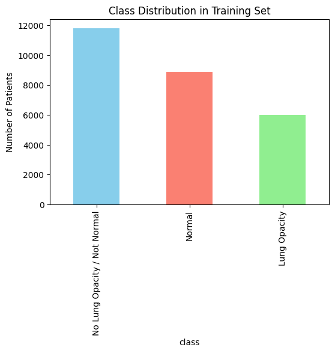

```python
plt.figure(figsize=(6,4))
class_counts = class_info_df["class"].value_counts()
class_counts.plot(kind="bar", color=["skyblue", "salmon", "lightgreen"])
plt.title("Class Distribution in Training Set")
plt.ylabel("Number of Patients")
plt.xticks(rotation=90)
plt.show()
```

```python
class_info_df["class"].value_counts()
```

| class | count |
| --- | --- |
| No Lung Opacity / Not Normal | 11821 |
| Normal | 8851 |
| Lung Opacity | 6012 |

**dtype:** int64

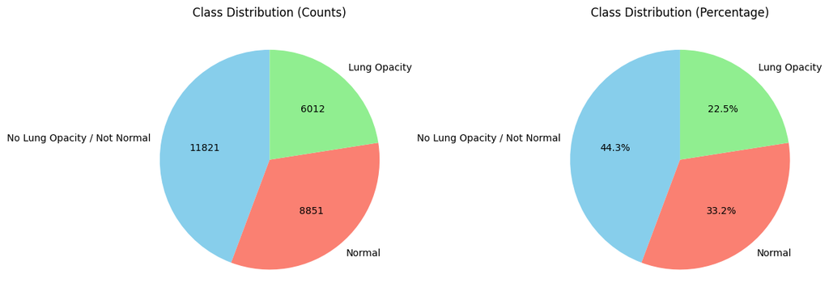

```python
colors = ["skyblue", "salmon", "lightgreen"]

# Create subplots
fig, axes = plt.subplots(1, 2, figsize=(12, 6))

# Pie chart 1: Counts
axes[0].pie(
    class_counts,
    labels=class_counts.index,
    autopct=lambda p: f'{int(p*sum(class_counts)/100)}',  # show counts
    colors=colors,
    startangle=90   # 🔹 same start angle
)
axes[0].set_title("Class Distribution (Counts)")

# Pie chart 2: Percentages
axes[1].pie(
    class_counts,
    labels=class_counts.index,
    autopct='%1.1f%%',
    colors=colors,
    startangle=90   # 🔹 same start angle
)
axes[1].set_title("Class Distribution (Percentage)")

plt.tight_layout()
plt.show()
```

##### **Observations:**

- The dataset is imbalanced, with "No Lung Opacity / Not Normal" having nearly double the samples compared to "Lung Opacity."
- Such imbalance may bias the model towards the majority class, so techniques like class weighting, data augmentation, or oversampling minority classes may be needed during training.

#### **Visualization Support Function**

```python
# Function to visualize image from ZIP

def visualize_sample_from_zip(zip_path, patient_id=None, cls=None, annotations=None):
    with zipfile.ZipFile(zip_path, 'r') as zip_ref:
        if patient_id:
            matches = [name for name in zip_ref.namelist() if patient_id in name]
            if not matches:
                print(f"No file found for {patient_id}")
                return
            file_to_read = matches[0]
        else:
            # Random file for test set
            file_to_read = random.choice(zip_ref.namelist())

        try:
            with zip_ref.open(file_to_read) as f:
                dicom_data = pydicom.dcmread(BytesIO(f.read()), force=True)
            img = dicom_data.pixel_array
        except Exception as e:
            print(f"Skipping {file_to_read}: {e}")
            return

        plt.imshow(img, cmap='gray')
        title = f"{'Train' if patient_id else 'Test'} Image - {patient_id or file_to_read}"
        plt.title(title)

        # Add bounding boxes if annotations exist
        if cls == "Lung Opacity" and annotations is not None and len(annotations) > 0:
            for (x, y, w, h) in annotations:
                plt.gca().add_patch(plt.Rectangle(
                    (x, y), w, h, fill=False, color="red", linewidth=2
                ))
        plt.axis('off')
        plt.show()
```

#### **Train Samples Visualization**

```
TRAIN IMAGE SAMPLES


Class: No Lung Opacity / Not Normal, Patient ID: 190900eb-b076-49cf-85a2-7bc41571e5aa
```

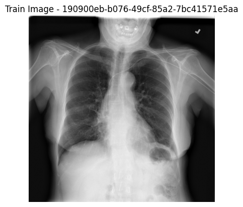

```
Class: Normal, Patient ID: 9f4cb263-83c4-494f-8b30-dfcb03efc791
```

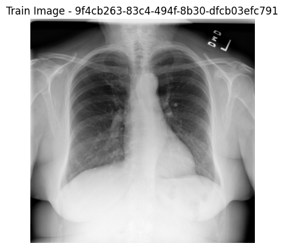

```
Class: Lung Opacity, Patient ID: 80314888-a5ec-4ba1-8cf4-ad9c67fac5ba
```

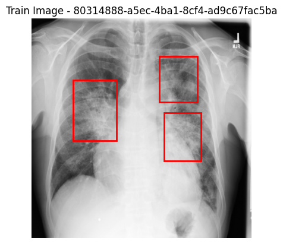

```python
# Train samples visualization
print("TRAIN IMAGE SAMPLES")
for cls in class_info_df['class'].unique():
    sample_pid = random.choice(class_info_df[class_info_df["class"] == cls]["patientId"].values)
    if cls == "Lung Opacity":
        annots = labels_df[labels_df["patientId"] == sample_pid][["x", "y", "width", "height"]].values
    else:
        annots = None
    print(f"\n\nClass: {cls}, Patient ID: {sample_pid}")
    visualize_sample_from_zip(train_zip_path, sample_pid, cls, annots)
```

#### **Test Samples Visualization**

```
TEST IMAGE SAMPLES
Skipping __MACOSX/stage_2_test_images/._244d32fe-0280-45e3-90c0-60f344d99b48.dcm: Unable to decode the pixel data as the dataset's 'file_meta' has no (0002,0010) 'Transfer Syntax UID' element
```

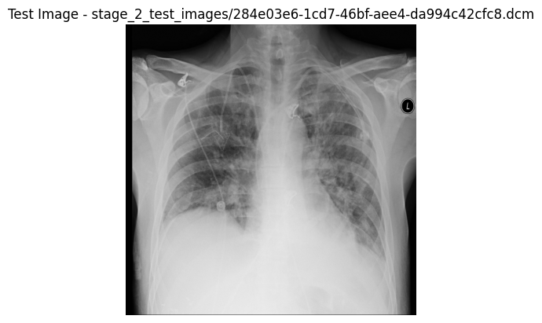

```
Skipping __MACOSX/stage_2_test_images/._2c5b8ef5-ebed-4b39-91e0-d59ec302503a.dcm: Unable to decode the pixel data as the dataset's 'file_meta' has no (0002,0010) 'Transfer Syntax UID' element
```

```python
# Test samples visualization
print("\nTEST IMAGE SAMPLES")
for _ in range(3):  # Show 3 random test samples
    visualize_sample_from_zip(test_zip_path)
```

### **Step 5:** **Display Images With Bounding Box**

#### **Display Train Images With Bounding Box**

```python
def get_image_from_zip(zip_path, patient_id):
    """Read DICOM image from ZIP and return as numpy array."""
    with zipfile.ZipFile(zip_path, 'r') as zip_ref:
        matches = [name for name in zip_ref.namelist() if patient_id in name]
        if not matches:
            return None
        file_name = matches[0]
        try:
            with zip_ref.open(file_name) as f:
                dicom_data = pydicom.dcmread(BytesIO(f.read()), force=True)
            return dicom_data.pixel_array
        except:
            return None
```

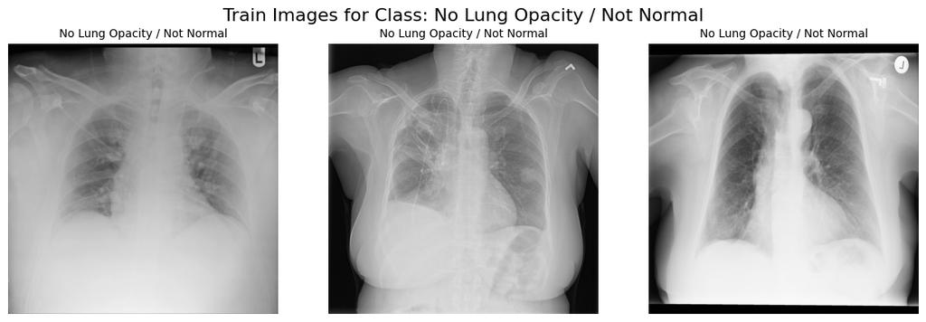

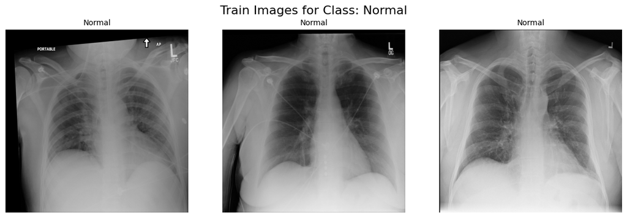

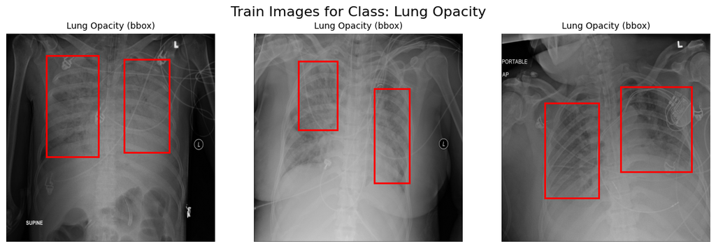

```python
# --- TRAIN IMAGES ---
train_classes = class_info_df['class'].unique()

for cls in train_classes:
    sample_ids = random.sample(
        list(class_info_df[class_info_df['class'] == cls]['patientId']), 3
    )
    imgs = []
    titles = []

    for pid in sample_ids:
        img = get_image_from_zip(train_zip_path, pid)
        if img is None:  # Skip missing images
            continue
        imgs.append(img)
        titles.append(cls)

    # Create subplot grid dynamically (only for available images)
    fig, axes = plt.subplots(1, len(imgs), figsize=(12, 4))
    if len(imgs) == 1:
        axes = [axes]  # keep iterable

    for ax, img, pid in zip(axes, imgs, sample_ids):
        ax.imshow(img, cmap='gray')
        ax.axis('off')
        title = cls

        # Add bounding boxes for Lung Opacity
        if cls == "Lung Opacity":
            annots = labels_df[labels_df["patientId"] == pid][["x", "y", "width", "height"]].values
            for (x, y, w, h) in annots:
                ax.add_patch(
                    plt.Rectangle((x, y), w, h, fill=False, color="red", linewidth=2)
                )
            title += " (bbox)"
        ax.set_title(title, fontsize=10)

    plt.suptitle(f"Train Images for Class: {cls}", fontsize=16)
    plt.tight_layout()
    plt.show()
```

#### **Display Test Images Without Bounding Box**

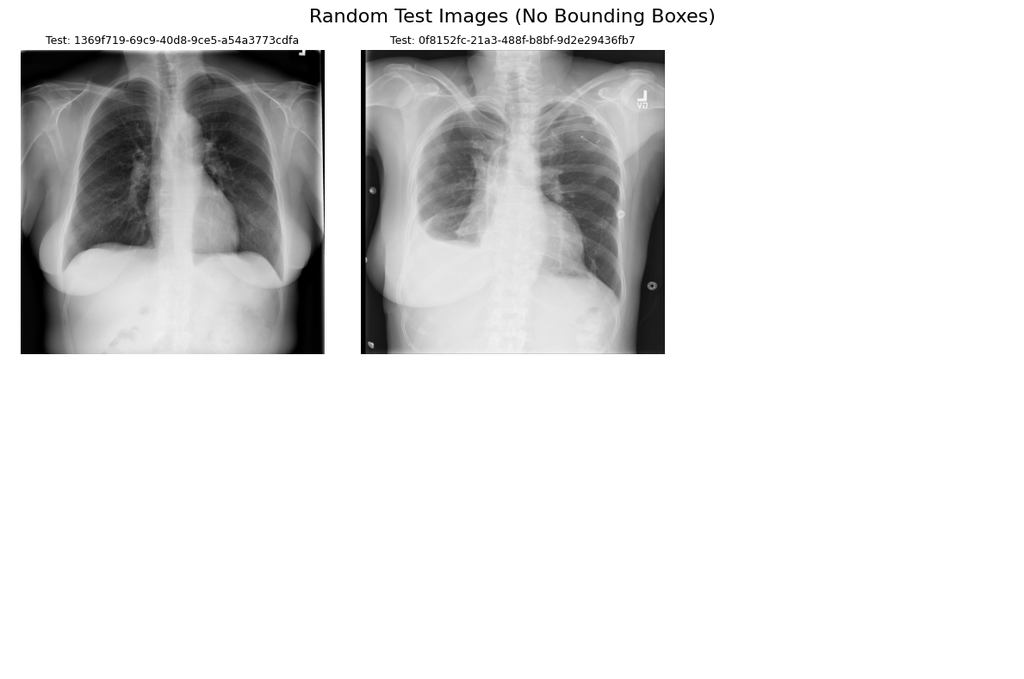

```python
# --- TEST IMAGES ---
with zipfile.ZipFile(test_zip_path, 'r') as test_zip:
    test_files = [f for f in test_zip.namelist() if f.lower().endswith(".dcm")]
    sample_test = random.sample(test_files, 6)  # Pick 6 random test files

# Store valid images & IDs
imgs, ids = [], []
for file_name in sample_test:
    patient_id = file_name.split("/")[-1].replace(".dcm", "")
    img = get_image_from_zip(test_zip_path, patient_id)
    if img is not None:  # Only keep valid images
        imgs.append(img)
        ids.append(patient_id)

# Adjust subplot grid based on available images
rows, cols = 2, 3
fig, axes = plt.subplots(rows, cols, figsize=(12, 8))

# Flatten axes for easier iteration
axes = axes.flatten()

for ax, img, pid in zip(axes, imgs, ids):
    ax.imshow(img, cmap='gray')
    ax.axis('off')
    ax.set_title(f"Test: {pid}", fontsize=9)

# Hide unused axes (if < 6 images are available)
for ax in axes[len(imgs):]:
    ax.axis('off')

plt.suptitle("Random Test Images (No Bounding Boxes)", fontsize=16)
plt.tight_layout()
plt.show()
```

#### **Observations:**

- A common issue in medical imaging datasets is that some images may be missing or not found. To handle this, our function is designed to skip missing images gracefully instead of breaking the pipeline.
- Possible Causes for Skipped Images:
  - Patient IDs listed in metadata but missing from the ZIP archive.
  - File name mismatches between the metadata CSV and actual DICOM/PNG files.
  - Corrupted or unreadable image files.
  - Mixed file formats (e.g., .dcm, .png, .jpg) not handled consistently.
  - DICOM parsing issues caused by unusual compression or encoding.

### **Step 6: Design, Train And Test Basic CNN Models For Classification**

#### **Model Design and Compilation**

```python
# Define model parameters
IMG_WIDTH = 224
IMG_HEIGHT = 224
IMG_CHANNELS = 3
input_shape = (IMG_WIDTH, IMG_HEIGHT, IMG_CHANNELS)

# Build the CNN model
model = Sequential([
    # Convolutional Block 1
    Conv2D(32, (3, 3), activation='relu', input_shape=input_shape),
    MaxPooling2D((2, 2)),

    # Convolutional Block 2
    Conv2D(64, (3, 3), activation='relu'),
    MaxPooling2D((2, 2)),

    # Convolutional Block 3
    Conv2D(128, (3, 3), activation='relu'),
    MaxPooling2D((2, 2)),

    # Flatten the feature maps to prepare for the dense layers
    Flatten(),

    # Fully Connected Layers
    Dense(512, activation='relu'),
    Dropout(0.5), # Add dropout for regularization to prevent overfitting
    Dense(1, activation='sigmoid') # Final output layer for binary classification
])

# Compile the model
model.compile(optimizer=Adam(learning_rate=0.0001),
              loss='binary_crossentropy',
              metrics=['accuracy'])

# Display the model's architecture
model.summary()
```

```
Model: "sequential"
```

```
┏━━━━━━━━━━━━━━━━━━━━━━━━━━━━━━━━━┳━━━━━━━━━━━━━━━━━━━━━━━━┳━━━━━━━━━━━━━━━┓
┃ Layer (type)                    ┃ Output Shape           ┃       Param # ┃
┡━━━━━━━━━━━━━━━━━━━━━━━━━━━━━━━━━╇━━━━━━━━━━━━━━━━━━━━━━━━╇━━━━━━━━━━━━━━━┩
│ conv2d (Conv2D)                 │ (None, 222, 222, 32)   │           896 │
├─────────────────────────────────┼────────────────────────┼───────────────┤
│ max_pooling2d (MaxPooling2D)    │ (None, 111, 111, 32)   │             0 │
├─────────────────────────────────┼────────────────────────┼───────────────┤
│ conv2d_1 (Conv2D)               │ (None, 109, 109, 64)   │        18,496 │
├─────────────────────────────────┼────────────────────────┼───────────────┤
│ max_pooling2d_1 (MaxPooling2D)  │ (None, 54, 54, 64)     │             0 │
├─────────────────────────────────┼────────────────────────┼───────────────┤
│ conv2d_2 (Conv2D)               │ (None, 52, 52, 128)    │        73,856 │
├─────────────────────────────────┼────────────────────────┼───────────────┤
│ max_pooling2d_2 (MaxPooling2D)  │ (None, 26, 26, 128)    │             0 │
├─────────────────────────────────┼────────────────────────┼───────────────┤
│ flatten (Flatten)               │ (None, 86528)          │             0 │
├─────────────────────────────────┼────────────────────────┼───────────────┤
│ dense (Dense)                   │ (None, 512)            │    44,302,848 │
├─────────────────────────────────┼────────────────────────┼───────────────┤
│ dropout (Dropout)               │ (None, 512)            │             0 │
├─────────────────────────────────┼────────────────────────┼───────────────┤
│ dense_1 (Dense)                 │ (None, 1)              │           513 │
└─────────────────────────────────┴────────────────────────┴───────────────┘
```

```
 Total params: 44,396,609 (169.36 MB)
```

```
 Trainable params: 44,396,609 (169.36 MB)
```

```
 Non-trainable params: 0 (0.00 B)
```

#### **Data Preparation for Training**

```python
def data_generator(df, zip_file, batch_size=32, target_size=(224, 224), datagen=None):
    """
    A generator that yields preprocessed images and labels in batches.
    """
    while True:
        # Get a random batch of data
        batch_df = df.sample(n=batch_size)

        images = []
        labels = []

        for _, row in batch_df.iterrows():
            patient_id = row['patientId']
            label = row['Target']

            # Read and process the DICOM image
            img = read_dicom_image(patient_id, zip_file, target_size)
            if img is not None:
                images.append(img)
                labels.append(label)

        if len(images) == 0:
            continue  # Skip if no valid images in batch

        images = np.array(images).astype('float32')  # Shape: (batch_size, 224, 224, 3)
        labels = np.array(labels)

        if datagen:
            # Apply augmentation properly
            images = next(datagen.flow(images, labels, batch_size=batch_size, shuffle=False))[0]

        # Normalize images to 0-1 range
        images = images / 255.0
        images = tf.convert_to_tensor(images)
        labels = tf.convert_to_tensor(labels)

        yield images, labels
```

#### **Training and Testing the model**

```python
# Assuming you have already created train_df and val_df
# from a previous step (train_test_split)

# Define batch size
BATCH_SIZE = 32

# Open the zip file once
archive = zipfile.ZipFile(train_zip_path, 'r')

# Create the data generators for training and validation
train_gen = data_generator(train_df, archive, batch_size=BATCH_SIZE)
val_gen = data_generator(val_df, archive, batch_size=BATCH_SIZE)

# Calculate steps per epoch to ensure a full pass through the data
train_steps = len(train_df) // BATCH_SIZE
val_steps = len(val_df) // BATCH_SIZE

# Train the model
history = model.fit(
    train_gen,
    steps_per_epoch=train_steps,
    epochs=10, # Number of epochs to train for
    validation_data=val_gen,
    validation_steps=val_steps
)

# Evaluate the model on the validation set
# Re-create the generator for evaluation to ensure data is read from the beginning
val_gen_eval = data_generator(val_df, archive, batch_size=BATCH_SIZE)
loss, accuracy = model.evaluate(val_gen_eval, steps=val_steps)
print(f"Validation Loss: {loss:.4f}")
print(f"Validation Accuracy: {accuracy:.4f}")

# After training, it's good practice to close the zip file
archive.close()
```

```
667/667 ━━━━━━━━━━━━━━━━━━━━ 463s 682ms/step - accuracy: 0.7864 - loss: 0.4671 - val_accuracy: 0.7946 - val_loss: 0.4296
667/667 ━━━━━━━━━━━━━━━━━━━━ 322s 484ms/step - accuracy: 0.7965 - loss: 0.4321 - val_accuracy: 0.8037 - val_loss: 0.4239
667/667 ━━━━━━━━━━━━━━━━━━━━ 324s 487ms/step - accuracy: 0.8090 - loss: 0.4150 - val_accuracy: 0.8059 - val_loss: 0.4193
667/667 ━━━━━━━━━━━━━━━━━━━━ 330s 495ms/step - accuracy: 0.8059 - loss: 0.4170 - val_accuracy: 0.8076 - val_loss: 0.4200
667/667 ━━━━━━━━━━━━━━━━━━━━ 381s 572ms/step - accuracy: 0.8215 - loss: 0.3904 - val_accuracy: 0.8010 - val_loss: 0.4219
667/667 ━━━━━━━━━━━━━━━━━━━━ 376s 565ms/step - accuracy: 0.8320 - loss: 0.3786 - val_accuracy: 0.8097 - val_loss: 0.4207
667/667 ━━━━━━━━━━━━━━━━━━━━ 322s 484ms/step - accuracy: 0.8405 - loss: 0.3566 - val_accuracy: 0.8119 - val_loss: 0.4253
667/667 ━━━━━━━━━━━━━━━━━━━━ 318s 478ms/step - accuracy: 0.8562 - loss: 0.3302 - val_accuracy: 0.7957 - val_loss: 0.4464
667/667 ━━━━━━━━━━━━━━━━━━━━ 310s 465ms/step - accuracy: 0.8655 - loss: 0.3072 - val_accuracy: 0.8021 - val_loss: 0.4468
667/667 ━━━━━━━━━━━━━━━━━━━━ 320s 480ms/step - accuracy: 0.8822 - loss: 0.2749 - val_accuracy: 0.8061 - val_loss: 0.4675
166/166 ━━━━━━━━━━━━━━━━━━━━ 61s 367ms/step - accuracy: 0.8006 - loss: 0.4749
Validation Loss: 0.4619
Validation Accuracy: 0.8065
```

#### **Save the Model**

```python
#Save Model
model.save('basic_cnn_model.keras')
print("Basic CNN Saved Successfully!")
```

```
Basic CNN Saved Successfully!
```

#### **Visualizing the Performance using the saved Model**

```python
from tensorflow.keras.models import load_model

# Load the model back
model = load_model('/content/drive/MyDrive/basic_cnn_model.keras')
print("Model loaded successfully!")
```

```
Model loaded successfully!
```

```python
# Get validation data and labels from the generator
# Re-create the generator to get a fresh batch of data
archive_eval = zipfile.ZipFile(train_zip_path, 'r') # Re-open the zip file for evaluation
# Create a generator to get the entire validation set as a single batch
val_gen_eval = data_generator(val_df, archive_eval, batch_size=len(val_df))
val_images, val_labels = next(val_gen_eval)
archive_eval.close() # Close the zip file after getting the data


# Get prediction probabilities
y_pred_probs = model.predict(val_images)

# Convert probabilities to binary labels (0 = No Pneumonia, 1 = Pneumonia)
y_pred = (y_pred_probs > 0.5).astype("int32")
```

```
167/167 ━━━━━━━━━━━━━━━━━━━━ 8s 25ms/step
```

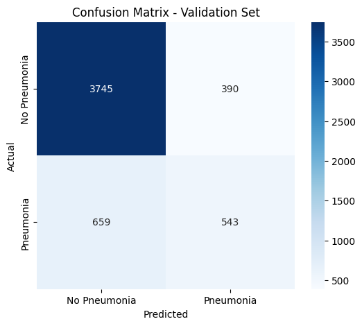

```
Classification Report:

              precision    recall  f1-score   support

No Pneumonia       0.85      0.91      0.88      4135
   Pneumonia       0.58      0.45      0.51      1202

    accuracy                           0.80      5337
   macro avg       0.72      0.68      0.69      5337
weighted avg       0.79      0.80      0.79      5337
```

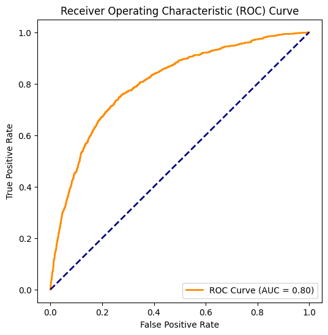

```python
from sklearn.metrics import classification_report, confusion_matrix, roc_curve, auc
import matplotlib.pyplot as plt
import seaborn as sns

# Get validation data and labels from the generator
# These variables are expected to be defined in the previous cell (ZEcJ-0ulUl65)

# -------------------------------
# Confusion Matrix
# -------------------------------
cm = confusion_matrix(val_labels, y_pred)

plt.figure(figsize=(6,5))
sns.heatmap(cm, annot=True, fmt="d", cmap="Blues",
            xticklabels=["No Pneumonia","Pneumonia"],
            yticklabels=["No Pneumonia","Pneumonia"])
plt.xlabel("Predicted")
plt.ylabel("Actual")
plt.title("Confusion Matrix - Validation Set")
plt.show()

# -------------------------------
# Classification Report
# -------------------------------
print("Classification Report:\n")
print(classification_report(val_labels, y_pred, target_names=["No Pneumonia","Pneumonia"]))

# -------------------------------
# ROC Curve
# -------------------------------
fpr, tpr, thresholds = roc_curve(val_labels, y_pred_probs)
roc_auc = auc(fpr, tpr)

plt.figure(figsize=(6,6))
plt.plot(fpr, tpr, color="darkorange", lw=2, label=f"ROC Curve (AUC = {roc_auc:.2f})")
plt.plot([0,1], [0,1], color="navy", lw=2, linestyle="--")
plt.xlabel("False Positive Rate")
plt.ylabel("True Positive Rate")
plt.title("Receiver Operating Characteristic (ROC) Curve")
plt.legend(loc="lower right")
plt.show()
```

**Observations:**

**Feature Learning:** The model appears to capture relevant features (such as lung opacities) early in training, which aligns with its strong ability to classify No Pneumonia cases.

**Generalization Gap:** A sharp divergence between training and validation performance after Epoch 3 suggests overfitting — the model is memorizing training data instead of learning robust, generalizable patterns.

**Model Complexity:** The presence of a very large fully connected layer (~44M parameters) increases overfitting risk, especially with an imbalanced dataset where pneumonia cases are fewer.

**Clinical Implication:** High false negatives (missed pneumonia cases) are concerning in a healthcare setting, meaning the current model is safer for ruling out pneumonia than for confidently diagnosing it.

#### **Key Insights and Observation**

**Next Steps and Recommendations**

- To mitigate overfitting and improve your model's performance, consider these strategies:

  **Early Stopping:** We should stop training when the validation loss starts to increase. Based on these results, training past Epoch 3 doesn't improve performance on unseen data. We can implement a Keras Callback for early stopping to automate this process.

  **Regularization:** The model has a dropout layer, but we may need more aggressive regularization. We can consider adding more dropout layers or increasing the dropout rate. We can also introduce L1 or L2 regularization to your convolutional or dense layers.

  **Data Augmentation:** We can apply diverse data augmentation techniques (e.g., rotations, shifts, zooms) to make the training data more varied and help the model generalize better.

```python
#Saving the model to drive
!cp basic_cnn_model.keras /content/drive/MyDrive/
```

## **Milestone 2**

### **Step 1: Fine tune the trained basic CNN models for classification**

##### **Load the model**

```python
from tensorflow.keras.models import load_model

# Load the previously saved model
fine_tune_model = load_model('/content/drive/MyDrive/basic_cnn_model.keras')
print("Model loaded successfully!")
```

```
Model loaded successfully!
```

#### **Set Up Data Generator for Fine-tuning**

```python
from tensorflow.keras.preprocessing.image import ImageDataGenerator

# Create an ImageDataGenerator with augmentation
train_datagen = ImageDataGenerator(
    rescale=1./255,
    rotation_range=15,
    width_shift_range=0.1,
    height_shift_range=0.1,
    zoom_range=0.1,
    horizontal_flip=True
)

val_datagen = ImageDataGenerator(rescale=1./255)
```

```python
archive = zipfile.ZipFile(train_zip_path, 'r')

BATCH_SIZE = 32

train_gen = data_generator(train_df, archive, batch_size=BATCH_SIZE, datagen=train_datagen)
val_gen = data_generator(val_df, archive, batch_size=BATCH_SIZE, datagen=val_datagen)

train_steps = len(train_df) // BATCH_SIZE
val_steps = len(val_df) // BATCH_SIZE
```

#### **Compile the Model**

```python
from tensorflow.keras.optimizers import Adam
from tensorflow.keras.callbacks import EarlyStopping

# Recompile model with a lower learning rate for fine-tuning
model.compile(
    optimizer=Adam(learning_rate=1e-5),
    loss='binary_crossentropy',
    metrics=['accuracy']
)

# Early stopping callback
early_stopping = EarlyStopping(monitor='val_loss', patience=3, restore_best_weights=True)
```

#### **Train the Fine Tune Model**

```python
history = fine_tune_model.fit(
    train_gen,
    steps_per_epoch=train_steps,
    epochs=10,
    validation_data=val_gen,
    validation_steps=val_steps,
    callbacks=[early_stopping]
)

# Close zip archive after training
archive.close()
```

```
667/667 ━━━━━━━━━━━━━━━━━━━━ 714s 1s/step - accuracy: 0.7773 - loss: 0.5493 - val_accuracy: 0.7816 - val_loss: 0.5244
667/667 ━━━━━━━━━━━━━━━━━━━━ 674s 1s/step - accuracy: 0.7754 - loss: 0.5405 - val_accuracy: 0.7773 - val_loss: 0.5290
667/667 ━━━━━━━━━━━━━━━━━━━━ 636s 955ms/step - accuracy: 0.7712 - loss: 0.5401 - val_accuracy: 0.7779 - val_loss: 0.5275
667/667 ━━━━━━━━━━━━━━━━━━━━ 648s 973ms/step - accuracy: 0.7734 - loss: 0.5361 - val_accuracy: 0.7722 - val_loss: 0.5329
```

#### **Save the Fine Tuned Model**

```python
fine_tune_model.save('/content/drive/MyDrive/fine_tuned_cnn_model.keras')
print("Fine-tuned model saved successfully!")
```

```
Fine-tuned model saved successfully!
```

### **Step 2: Apply Transfer Learning model for classification**

#### **MobileNetV2**

##### **Load Pre-trained Model (MobileNetV2)**

```python
import tensorflow as tf
from tensorflow.keras.applications import MobileNetV2
from tensorflow.keras.layers import Dense, GlobalAveragePooling2D
from tensorflow.keras.models import Model

# Load the base pretrained model
base_model = MobileNetV2(input_shape=(224, 224, 3),
                         include_top=False,
                         weights='imagenet')

# Freeze the convolutional base
base_model.trainable = False

# Add classification head
x = base_model.output
x = GlobalAveragePooling2D()(x)
x = Dense(128, activation='relu')(x)
output = Dense(1, activation='sigmoid')(x)

transfer_learning_model = Model(inputs=base_model.input, outputs=output)
```

##### **Compile the Model**

```python
from tensorflow.keras.optimizers import Adam
from tensorflow.keras.callbacks import EarlyStopping

transfer_learning_model.compile(
    optimizer=Adam(learning_rate=1e-4),
    loss='binary_crossentropy',
    metrics=['accuracy']
)

early_stopping = EarlyStopping(monitor='val_loss', patience=3, restore_best_weights=True)
```

##### **Prepare Data Generators**

```python
import zipfile

archive = zipfile.ZipFile(train_zip_path, 'r')

BATCH_SIZE = 32

# Data augmentation for training
train_datagen = tf.keras.preprocessing.image.ImageDataGenerator(
    rotation_range=15,
    width_shift_range=0.1,
    height_shift_range=0.1,
    zoom_range=0.1,
    horizontal_flip=True
)

# No augmentation for validation
val_datagen = tf.keras.preprocessing.image.ImageDataGenerator()

train_gen = data_generator(train_df, archive, batch_size=BATCH_SIZE, datagen=train_datagen)
val_gen = data_generator(val_df, archive, batch_size=BATCH_SIZE, datagen=val_datagen)

train_steps = len(train_df) // BATCH_SIZE
val_steps = len(val_df) // BATCH_SIZE
```

##### **Train the Transfer Learning Model**

```python
history = transfer_learning_model.fit(
    train_gen,
    steps_per_epoch=train_steps,
    epochs=10,
    validation_data=val_gen,
    validation_steps=val_steps,
    callbacks=[early_stopping]
)
```

```
667/667 ━━━━━━━━━━━━━━━━━━━━ 601s 877ms/step - accuracy: 0.7635 - loss: 0.4926 - val_accuracy: 0.8023 - val_loss: 0.4118
667/667 ━━━━━━━━━━━━━━━━━━━━ 622s 933ms/step - accuracy: 0.8084 - loss: 0.4108 - val_accuracy: 0.7974 - val_loss: 0.4400
667/667 ━━━━━━━━━━━━━━━━━━━━ 575s 864ms/step - accuracy: 0.8142 - loss: 0.3976 - val_accuracy: 0.8069 - val_loss: 0.4069
667/667 ━━━━━━━━━━━━━━━━━━━━ 612s 919ms/step - accuracy: 0.8186 - loss: 0.3941 - val_accuracy: 0.8042 - val_loss: 0.4251
667/667 ━━━━━━━━━━━━━━━━━━━━ 611s 917ms/step - accuracy: 0.8164 - loss: 0.3991 - val_accuracy: 0.7978 - val_loss: 0.4279
667/667 ━━━━━━━━━━━━━━━━━━━━ 626s 940ms/step - accuracy: 0.8201 - loss: 0.3934 - val_accuracy: 0.8070 - val_loss: 0.4107
```

##### **Save the Trained Transfer Learning Model**

```python
transfer_learning_model.save('/content/drive/MyDrive/transfer_learning_model_mobilenetv2.keras')
print("Transfer learning model saved successfully!")
```

```
Transfer learning model saved successfully!
```

#### **RestNet50**

##### **Load Pre-trained Model (RestNet50)**

```python
import tensorflow as tf
from tensorflow.keras.applications import ResNet50
from tensorflow.keras.layers import Dense, GlobalAveragePooling2D
from tensorflow.keras.models import Model

# Load base ResNet50 without top layers
base_model = ResNet50(input_shape=(224, 224, 3),
                      include_top=False,
                      weights='imagenet')

# Freeze base model
base_model.trainable = False

# Add custom classification head
x = base_model.output
x = GlobalAveragePooling2D()(x)
x = Dense(128, activation='relu')(x)
output = Dense(1, activation='sigmoid')(x)

resnet_model = Model(inputs=base_model.input, outputs=output)
```

```
Downloading data from https://storage.googleapis.com/tensorflow/keras-applications/resnet/resnet50_weights_tf_dim_ordering_tf_kernels_notop.h5
94765736/94765736 ━━━━━━━━━━━━━━━━━━━━ 5s 0us/step
```

##### **Compile the Model**

```python
from tensorflow.keras.optimizers import Adam
from tensorflow.keras.callbacks import EarlyStopping

resnet_model.compile(
    optimizer=Adam(learning_rate=1e-4),
    loss='binary_crossentropy',
    metrics=['accuracy']
)

early_stopping = EarlyStopping(monitor='val_loss', patience=3, restore_best_weights=True)
```

##### **Prepare Data Generators**

```python
import zipfile

archive = zipfile.ZipFile(train_zip_path, 'r')

BATCH_SIZE = 32

# Data augmentation for training
train_datagen = tf.keras.preprocessing.image.ImageDataGenerator(
    rotation_range=15,
    width_shift_range=0.1,
    height_shift_range=0.1,
    zoom_range=0.1,
    horizontal_flip=True
)

# No augmentation for validation
val_datagen = tf.keras.preprocessing.image.ImageDataGenerator()

train_gen = data_generator(train_df, archive, batch_size=BATCH_SIZE, datagen=train_datagen)
val_gen = data_generator(val_df, archive, batch_size=BATCH_SIZE, datagen=val_datagen)

train_steps = len(train_df) // BATCH_SIZE
val_steps = len(val_df) // BATCH_SIZE
```

##### **Train the Transfer Learning Model**

```python
history = resnet_model.fit(
    train_gen,
    steps_per_epoch=train_steps,
    epochs=10,
    validation_data=val_gen,
    validation_steps=val_steps,
    callbacks=[early_stopping]
)
```

```
667/667 ━━━━━━━━━━━━━━━━━━━━ 616s 904ms/step - accuracy: 0.7650 - loss: 0.5481 - val_accuracy: 0.7816 - val_loss: 0.5136
667/667 ━━━━━━━━━━━━━━━━━━━━ 606s 910ms/step - accuracy: 0.7737 - loss: 0.5251 - val_accuracy: 0.7807 - val_loss: 0.5090
667/667 ━━━━━━━━━━━━━━━━━━━━ 628s 943ms/step - accuracy: 0.7764 - loss: 0.5145 - val_accuracy: 0.7758 - val_loss: 0.5102
667/667 ━━━━━━━━━━━━━━━━━━━━ 653s 980ms/step - accuracy: 0.7729 - loss: 0.5149 - val_accuracy: 0.7782 - val_loss: 0.5002
667/667 ━━━━━━━━━━━━━━━━━━━━ 676s 1s/step - accuracy: 0.7733 - loss: 0.5103 - val_accuracy: 0.7792 - val_loss: 0.4953
667/667 ━━━━━━━━━━━━━━━━━━━━ 657s 986ms/step - accuracy: 0.7667 - loss: 0.5157 - val_accuracy: 0.7664 - val_loss: 0.5078
667/667 ━━━━━━━━━━━━━━━━━━━━ 622s 933ms/step - accuracy: 0.7794 - loss: 0.4996 - val_accuracy: 0.7675 - val_loss: 0.5003
667/667 ━━━━━━━━━━━━━━━━━━━━ 610s 916ms/step - accuracy: 0.7765 - loss: 0.4957 - val_accuracy: 0.7660 - val_loss: 0.5055
```

##### **Save the Trained Transfer Learning Model**

```python
resnet_model.save('/content/drive/MyDrive/transfer_learning_model_resnet.keras')
print("ResNet50 transfer learning model saved successfully!")
```

```
ResNet50 transfer learning model saved successfully!
```

#### **DenseNet121**

##### **Load Pretrained Model**

```python
##### **Load Pre-trained Model (DenseNet121)**
import tensorflow as tf
from tensorflow.keras.applications import DenseNet121
from tensorflow.keras.layers import Dense, GlobalAveragePooling2D, Dropout
from tensorflow.keras.models import Model

# Load the base pretrained model
base_model = DenseNet121(input_shape=(224, 224, 3),
                         include_top=False,
                         weights='imagenet')

# Freeze the convolutional base
base_model.trainable = False

# Add classification head
x = base_model.output
x = GlobalAveragePooling2D()(x)
x = Dropout(0.5)(x)   # regularization to avoid overfitting
x = Dense(128, activation='relu')(x)
output = Dense(1, activation='sigmoid')(x)

transfer_learning_model = Model(inputs=base_model.input, outputs=output)
```

```
Downloading data from https://storage.googleapis.com/tensorflow/keras-applications/densenet/densenet121_weights_tf_dim_ordering_tf_kernels_notop.h5
29084464/29084464 ━━━━━━━━━━━━━━━━━━━━ 0s 0us/step
```

##### **Compile the model**

```python
##### **Compile the Model**
from tensorflow.keras.optimizers import Adam
from tensorflow.keras.callbacks import EarlyStopping

transfer_learning_model.compile(
    optimizer=Adam(learning_rate=1e-4),
    loss='binary_crossentropy',
    metrics=['accuracy']
)

early_stopping = EarlyStopping(monitor='val_loss', patience=3, restore_best_weights=True)
```

##### **Prepare Data Generators**

```python
##### **Prepare Data Generators**
import zipfile

archive = zipfile.ZipFile(train_zip_path, 'r')

BATCH_SIZE = 32

# Data augmentation for training
train_datagen = tf.keras.preprocessing.image.ImageDataGenerator(
    rotation_range=15,
    width_shift_range=0.1,
    height_shift_range=0.1,
    zoom_range=0.1,
    horizontal_flip=True
)

# No augmentation for validation
val_datagen = tf.keras.preprocessing.image.ImageDataGenerator()

train_gen = data_generator(train_df, archive, batch_size=BATCH_SIZE, datagen=train_datagen)
val_gen = data_generator(val_df, archive, batch_size=BATCH_SIZE, datagen=val_datagen)

train_steps = len(train_df) // BATCH_SIZE
val_steps = len(val_df) // BATCH_SIZE
```

##### **Train the Transfer Training Model**

```python
##### **Train the Transfer Learning Model**
history = transfer_learning_model.fit(
    train_gen,
    steps_per_epoch=train_steps,
    epochs=10,
    validation_data=val_gen,
    validation_steps=val_steps,
    callbacks=[early_stopping]
)
```

```
667/667 ━━━━━━━━━━━━━━━━━━━━ 635s 909ms/step - accuracy: 0.7588 - loss: 0.5230 - val_accuracy: 0.8089 - val_loss: 0.4224
667/667 ━━━━━━━━━━━━━━━━━━━━ 590s 886ms/step - accuracy: 0.7818 - loss: 0.4624 - val_accuracy: 0.7959 - val_loss: 0.4331
667/667 ━━━━━━━━━━━━━━━━━━━━ 629s 945ms/step - accuracy: 0.7932 - loss: 0.4426 - val_accuracy: 0.8119 - val_loss: 0.4133
667/667 ━━━━━━━━━━━━━━━━━━━━ 605s 909ms/step - accuracy: 0.7965 - loss: 0.4387 - val_accuracy: 0.8006 - val_loss: 0.4245
667/667 ━━━━━━━━━━━━━━━━━━━━ 618s 928ms/step - accuracy: 0.7967 - loss: 0.4359 - val_accuracy: 0.8112 - val_loss: 0.4097
667/667 ━━━━━━━━━━━━━━━━━━━━ 631s 947ms/step - accuracy: 0.7942 - loss: 0.4331 - val_accuracy: 0.8046 - val_loss: 0.4152
667/667 ━━━━━━━━━━━━━━━━━━━━ 614s 922ms/step - accuracy: 0.7959 - loss: 0.4369 - val_accuracy: 0.8146 - val_loss: 0.4023
667/667 ━━━━━━━━━━━━━━━━━━━━ 621s 933ms/step - accuracy: 0.7921 - loss: 0.4422 - val_accuracy: 0.8180 - val_loss: 0.4063
667/667 ━━━━━━━━━━━━━━━━━━━━ 624s 937ms/step - accuracy: 0.7944 - loss: 0.4356 - val_accuracy: 0.8112 - val_loss: 0.4132
667/667 ━━━━━━━━━━━━━━━━━━━━ 636s 954ms/step - accuracy: 0.7865 - loss: 0.4511 - val_accuracy: 0.8163 - val_loss: 0.4024
```

##### **Save the trained Transfer Training Model**

```python
##### **Save the Trained Transfer Learning Model**
transfer_learning_model.save('/content/drive/MyDrive/transfer_learning_model_densenet121.keras')
print("DenseNet121 transfer learning model saved successfully!")
```

```
DenseNet121 transfer learning model saved successfully!
```

#### **Compare the Models (Basic CNN, Fine Tuned CNN, Transfer Learning Model MobileNet2, RestNet50, and DenseNet121)**

##### **Load the Saved Models**

```python
from tensorflow.keras.models import load_model

mobilenet_model = load_model('/content/drive/MyDrive/transfer_learning_model_mobilenetv2.keras')
resnet_model     = load_model('/content/drive/MyDrive/transfer_learning_model_resnet.keras')
densenet121_model  = load_model('/content/drive/MyDrive/transfer_learning_model_densenet121.keras')
fine_tuned_model = load_model('/content/drive/MyDrive/fine_tuned_cnn_model.keras')
basic_cnn_model  = load_model('/content/drive/MyDrive/basic_cnn_model.keras')
```

```python
models = {
    'MobileNetV2': mobilenet_model,
    'ResNet50': resnet_model,
    'DenseNet121': densenet121_model,
    'Fine-Tuned CNN': fine_tuned_model,
    'Basic CNN': basic_cnn_model
}
```

##### **Prepare Validation Data Generator**

```python
import zipfile

archive = zipfile.ZipFile(train_zip_path, 'r')

BATCH_SIZE = 32

from tensorflow.keras.preprocessing.image import ImageDataGenerator

val_datagen = ImageDataGenerator()

val_gen = data_generator(val_df, archive, batch_size=BATCH_SIZE, datagen=val_datagen)
val_steps = len(val_df) // BATCH_SIZE
```

##### **Evaluate All Models**

```python
!pip install tqdm
```

```python
from tqdm import tqdm
from sklearn.metrics import classification_report, roc_auc_score, confusion_matrix
import pandas as pd

results = []

for model_name, model in models.items():
    print(f"\nEvaluating {model_name}...\n")

    y_true = []
    y_probs = []  # raw probabilities

    # Collect predictions across validation steps
    for _ in tqdm(range(val_steps), desc=f"Evaluating {model_name}"):
        X_val, y_val = next(val_gen)
        preds = model.predict(X_val, verbose=0).flatten()  # predicted probabilities
        y_probs.extend(preds)
        y_true.extend(y_val.numpy())

    # Convert probabilities to binary predictions
    y_pred = [1 if p > 0.5 else 0 for p in y_probs]

    # === Metrics ===
    accuracy = sum([yt == yp for yt, yp in zip(y_true, y_pred)]) / len(y_true)
    roc_auc = roc_auc_score(y_true, y_probs)  # use probs, not bin
    cm = confusion_matrix(y_true, y_pred)

    # Extract precision, recall, f1 from classification report
    report = classification_report(y_true, y_pred, output_dict=True, zero_division=0)
    precision = report['1']['precision']
    recall = report['1']['recall']
    f1 = report['1']['f1-score']

    # === Save all results ===
    results.append({
        'Model': model_name,
        'Accuracy': accuracy,
        'Precision': precision,
        'Recall': recall,
        'F1-Score': f1,
        'ROC AUC': roc_auc,
        'Confusion Matrix': cm,
        'y_true': y_true,
        'y_pred': y_pred,
        'y_prob': y_probs
    })
```

```
Evaluating MobileNetV2...
```

```
Evaluating ResNet50...
```

```
Evaluating DenseNet121...
```

```
Evaluating Fine-Tuned CNN...
```

```
Evaluating Basic CNN...
```

##### **Visualize the Comparison**

```
=== Model Performance Comparison ===

            Model  Accuracy  Precision    Recall  F1-Score   ROC AUC
0     MobileNetV2  0.810994   0.705882  0.271584  0.392252  0.830803
1        ResNet50  0.783509   0.000000  0.000000  0.000000  0.711653
2     DenseNet121  0.806664   0.596054  0.473597  0.527816  0.818288
3  Fine-Tuned CNN  0.798569   0.588032  0.417825  0.488528  0.784501
4       Basic CNN  0.801581   0.581856  0.460776  0.514286  0.797494
```

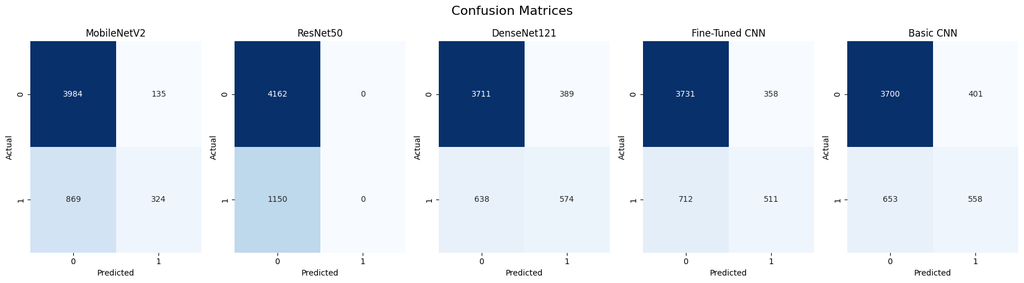

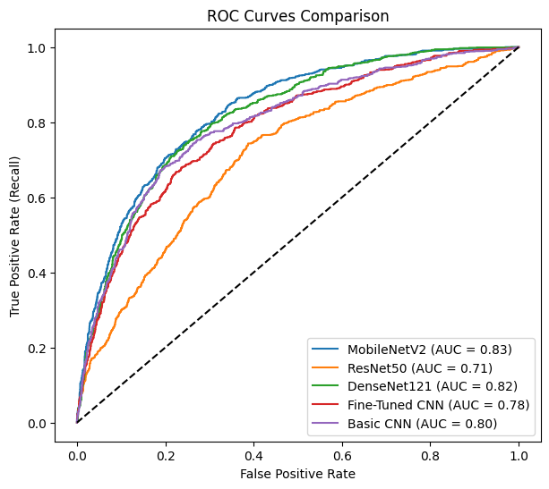

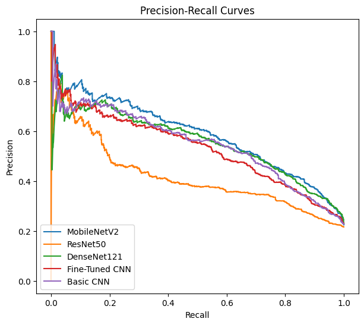

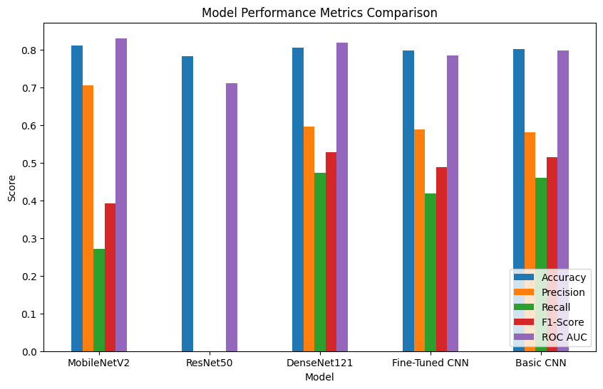

```python
import pandas as pd
import matplotlib.pyplot as plt
import seaborn as sns
from sklearn.metrics import confusion_matrix, roc_curve, auc, precision_recall_curve

# Assuming you already have predictions and labels for each model
# Example structure (replace with your actual stored values):
# results = [
#   {"Model": "MobileNetV2", "Accuracy": acc1, "Precision": prec1, "Recall": rec1, "F1-Score": f1_1, "ROC AUC": auc1,
#    "y_true": y_true1, "y_pred": y_pred1, "y_prob": y_prob1},
#   {"Model": "ResNet50", ...},
#   ...
# ]

df_results = pd.DataFrame(results)
pd.set_option('display.max_colwidth', None)

print("\n=== Model Performance Comparison ===\n")
print(df_results[['Model', 'Accuracy', 'Precision', 'Recall', 'F1-Score', 'ROC AUC']])

# ==============================
# 1. Confusion Matrices
# ==============================
fig, axes = plt.subplots(1, len(results), figsize=(18, 5))
for i, res in enumerate(results):
    cm = confusion_matrix(res["y_true"], res["y_pred"])
    sns.heatmap(cm, annot=True, fmt="d", cmap="Blues", cbar=False, ax=axes[i])
    axes[i].set_title(res["Model"])
    axes[i].set_xlabel("Predicted")
    axes[i].set_ylabel("Actual")
plt.suptitle("Confusion Matrices", fontsize=16)
plt.tight_layout()
plt.show()

# ==============================
# 2. ROC Curves
# ==============================
plt.figure(figsize=(7, 6))
for res in results:
    fpr, tpr, _ = roc_curve(res["y_true"], res["y_prob"])
    roc_auc = auc(fpr, tpr)
    plt.plot(fpr, tpr, label=f"{res['Model']} (AUC = {roc_auc:.2f})")

plt.plot([0, 1], [0, 1], 'k--')  # random baseline
plt.xlabel("False Positive Rate")
plt.ylabel("True Positive Rate (Recall)")
plt.title("ROC Curves Comparison")
plt.legend(loc="lower right")
plt.show()

# ==============================
# 3. Precision-Recall Curves
# ==============================
plt.figure(figsize=(7, 6))
for res in results:
    precision, recall, _ = precision_recall_curve(res["y_true"], res["y_prob"])
    plt.plot(recall, precision, label=res["Model"])

plt.xlabel("Recall")
plt.ylabel("Precision")
plt.title("Precision-Recall Curves")
plt.legend(loc="lower left")
plt.show()

# ==============================
# 4. Bar Chart for Metrics
# ==============================
metrics = ["Accuracy", "Precision", "Recall", "F1-Score", "ROC AUC"]
df_results.set_index("Model")[metrics].plot(kind="bar", figsize=(10, 6))
plt.title("Model Performance Metrics Comparison")
plt.ylabel("Score")
plt.xticks(rotation=0)
plt.legend(loc="lower right")
plt.show()
```

#### **Key Insighs and Recommendations**

##### **Base CNN Vs Fine Tuned CNN**

| Metric | Base CNN | Fine-Tuned CNN | Observation |
| --- | --- | --- | --- |
| Accuracy | 0.802 | 0.799 | Very similar, Base CNN slightly higher |
| Precision | 0.582 | 0.588 | Fine-Tuned CNN slightly better |
| Recall | 0.461 | 0.418 | Base CNN clearly better at detecting pneumonia cases |
| F1-Score | 0.514 | 0.489 | Base CNN stronger overall balance |
| ROC AUC | 0.797 | 0.785 | Base CNN has a slight edge in discrimination ability |

**Insights:**

- Base CNN performed better in recall, F1, and ROC AUC, meaning it is more balanced and reliable for medical screening.
- Fine-Tuned CNN gained a small bump in precision but lost recall, suggesting that fine-tuning made it more conservative → predicts fewer positives, thus missing more pneumonia cases.
- The performance gap indicates that the fine-tuning setup may not have been optimal (e.g., wrong learning rate, overfitting, or insufficient epochs).

**Recommendation**

- It is recommended to stick with the Base CNN if choosing between these two. The Base CNN actually outperformed the Fine-Tuned CNN overall, showing that in this case, fine-tuning did not improve results and may have hurt recall.
- Revisit the fine-tuning strategy:
  - Try freezing fewer layers initially.
  - Use a lower learning rate for fine-tuned layers.
  - Apply stronger augmentation to prevent overfitting.

##### **Comparison of all the Models**

**Key Insights:**

- **DenseNet121**
  - Highest recall (0.47) and F1-score (0.53).
  - Strong balance between detecting pneumonia and avoiding false positives.
  - Reliable for medical use where missing cases is risky.
- **MobileNetV2**
  - Best accuracy (81.1%), precision (0.71), and ROC AUC (0.83).
  - Struggles with recall (0.27) → misses many pneumonia cases.
  - Good when computational efficiency and avoiding false alarms matter.
- **Basic CNN**
  - Consistent baseline with balanced recall (0.46) and F1 (0.51).
  - Close to DenseNet121 in performance.
  - Simpler architecture, easier to train and deploy.
- **Fine-Tuned CNN**
  - Moderate recall (0.42) and F1 (0.49).
  - Slightly weaker than Basic CNN despite fine-tuning.
  - Suggests possible overfitting or suboptimal tuning.
- **ResNet50**
  - Very poor recall and F1 (both 0).
  - Model predicts almost everything as negative.
  - Likely miscalibrated threshold, poor training setup, or insufficient augmentation.

**Observation:**

**Recommendations:**

#### 🏆 Model Performance Ranking (Key Strengths)

| Rank | Model | Key Strength |
| --- | --- | --- |
| 🥇 1 | **DenseNet121** | Best overall balance (recall + precision) |
| 🥈 2 | **MobileNetV2** | Highest precision & ROC AUC |
| 🥉 3 | **Basic CNN** | Strong baseline, balanced performance |
| 4 | **Fine-Tuned CNN** | Decent performer, moderate recall |
| ❌ 5 | **ResNet50** | Poor at detecting positives (needs tuning) |

**Final Takeaway:**

For medical screening of pneumonia, **DenseNet121** is the best single model, but an **ensemble with MobileNetV2** could yield the most clinically reliable results.

### **Step 3: Design, train and test RCNN & its hybrids based object detection models to impose the bounding box or mask over the area of interest.**

#### **Install YOLOv5**

```python
!git clone https://github.com/ultralytics/yolov5.git
%cd yolov5
!pip install -r requirements.txt
```

```
Cloning into 'yolov5'...
remote: Enumerating objects: 17581, done.
remote: Counting objects: 100% (71/71), done.
remote: Compressing objects: 100% (61/61), done.
remote: Total 17581 (delta 40), reused 12 (delta 10), pack-reused 17510 (from 3)
Receiving objects: 100% (17581/17581), 16.66 MiB | 17.23 MiB/s, done.
Resolving deltas: 100% (12042/12042), done.
/content/yolov5
Downloading thop-0.1.1.post2209072238-py3-none-any.whl (15 kB)
Downloading ultralytics-8.3.199-py3-none-any.whl (1.1 MB)
   ━━━━━━━━━━━━━━━━━━━━━━━━━━━━━━━━━━━━━━━━ 1.1/1.1 MB 51.1 MB/s eta 0:00:00
Downloading ultralytics_thop-2.0.17-py3-none-any.whl (28 kB)
```

#### **Cleanup Corrupt Images**

```python
valid_patient_ids = []
total_ids = len(labels_df['patientId'].unique())

for idx, pid in enumerate(labels_df['patientId'].unique(), 1):
    try:
        file_path_in_zip = f'stage_2_train_images/{pid}.dcm'
        with archive.open(file_path_in_zip) as file:
            dicom_data = pydicom.dcmread(BytesIO(file.read()))
            _ = dicom_data.pixel_array  # Trigger read to detect corrupt files
        valid_patient_ids.append(pid)
    except Exception as e:
        print(f"Corrupt image skipped: {pid}")

    # Print progress every 100 files
    if idx % 2000 == 0 or idx == total_ids:
        print(f"Processed {idx}/{total_ids} patient IDs.")

print(f"Valid images found: {len(valid_patient_ids)} out of {total_ids}")
```

```
Processed 2000/26684 patient IDs.
Processed 4000/26684 patient IDs.
Processed 6000/26684 patient IDs.
Processed 8000/26684 patient IDs.
Processed 10000/26684 patient IDs.
Processed 12000/26684 patient IDs.
Processed 14000/26684 patient IDs.
Processed 16000/26684 patient IDs.
Processed 18000/26684 patient IDs.
Processed 20000/26684 patient IDs.
Processed 22000/26684 patient IDs.
Processed 24000/26684 patient IDs.
Processed 26000/26684 patient IDs.
Processed 26684/26684 patient IDs.
Valid images found: 26684 out of 26684
```

#### **Data Preparation**

```python
from tqdm import tqdm  # nice progress bar

train_ids, val_ids = train_test_split(labels_df['patientId'].unique(), test_size=0.2, random_state=42)

def convert_annotations(labels_df, archive, output_dir, target_size=(640, 640)):
    os.makedirs(f'{output_dir}/images/train', exist_ok=True)
    os.makedirs(f'{output_dir}/images/val', exist_ok=True)
    os.makedirs(f'{output_dir}/labels/train', exist_ok=True)
    os.makedirs(f'{output_dir}/labels/val', exist_ok=True)

    for split, ids in [('train', train_ids), ('val', val_ids)]:
        print(f"Processing {split} split with {len(ids)} images...")
        for idx, pid in enumerate(tqdm(ids, desc=f"Converting {split} images")):
            img_path = f'{output_dir}/images/{split}/{pid}.jpg'
            label_path = f'{output_dir}/labels/{split}/{pid}.txt'

            file_path_in_zip = f'stage_2_train_images/{pid}.dcm'
            with archive.open(file_path_in_zip) as file:
                dicom_data = pydicom.dcmread(BytesIO(file.read()))
                img = dicom_data.pixel_array
                img = (img - img.min()) / (img.max() - img.min()) * 255.0
                img = cv2.convertScaleAbs(img)
                img = cv2.resize(img, target_size)
                cv2.imwrite(img_path, img)

            ann_rows = labels_df[labels_df['patientId'] == pid]
            lines = []
            for _, row in ann_rows.iterrows():
                x, y, w, h = row['x'], row['y'], row['width'], row['height']
                x_center = (x + w / 2) / dicom_data.Columns
                y_center = (y + h / 2) / dicom_data.Rows
                norm_w = w / dicom_data.Columns
                norm_h = h / dicom_data.Rows
                lines.append(f"0 {x_center} {y_center} {norm_w} {norm_h}")

            with open(label_path, 'w') as f:
                f.write('\n'.join(lines))

    print("\nData preparation completed successfully.")
```

```python
# Step 0: Clean up old dataset folders
import shutil

output_dir = '/content/drive/MyDrive/dataset'

for folder in ['images/train', 'images/val', 'labels/train', 'labels/val']:
    folder_path = f'{output_dir}/{folder}'
    if os.path.exists(folder_path):
        shutil.rmtree(folder_path)
        print(f"Deleted folder: {folder_path}")
```

```
Deleted folder: /content/drive/MyDrive/dataset/images/train
Deleted folder: /content/drive/MyDrive/dataset/images/val
Deleted folder: /content/drive/MyDrive/dataset/labels/train
Deleted folder: /content/drive/MyDrive/dataset/labels/val
```

```python
convert_annotations(
    labels_df=labels_df,
    archive=archive,
    output_dir='/content/drive/MyDrive/dataset',
    target_size=(640, 640)
)
print("Data preparation completed.")
```

```
Processing train split with 21347 images...
```

```
Processing val split with 5337 images...
```

```
Data preparation completed successfully.
Data preparation completed.
```

#### **Generate data.yaml for YOLO**

```python
data_yaml = """
train: /content/drive/MyDrive/dataset/images/train
val: /content/drive/MyDrive/dataset/images/val

nc: 1
names: ['Pneumonia']
"""

with open('/content/drive/MyDrive/dataset/data.yaml', 'w') as f:
    f.write(data_yaml)

print("data.yaml file created.")
```

```
data.yaml file created.
```

#### **Train YOLO Object Detection Model**

```python
import os
os.environ['WANDB_MODE'] = 'offline'  # Disable WandB logging

!python /content/yolov5/train.py \
    --img 640 \
    --batch 16 \
    --epochs 10 \
    --data /content/drive/MyDrive/dataset/data.yaml \
    --weights yolov5s.pt \
    --project /content/drive/MyDrive/yolov5_pneumonia \
    --name exp_pneumonia \
    --exist-ok
```

**Note:** Cleared the output for html generation. the output was 5000+ lines. Please refer to the uploaded .ipynb file for the output.

#### **Test the Trained Model**

```python
!python /content/yolov5/detect.py \
    --weights /content/drive/MyDrive/yolov5_pneumonia/exp_pneumonia/weights/best.pt \
    --img 640 \
    --conf 0.25 \
    --source /content/drive/MyDrive/dataset/images/val \
    --project /content/drive/MyDrive/yolov5_pneumonia/results \
    --name pneumonia_detection
```

**Note:** Cleared the output for html generation. the output was 5000+ lines. Please refer to the uploaded .ipynb file for the output.

#### **Display Original & Predicted Images Side by Side**

```
Total result images available: 5337
Images with bounding boxes: 5337
```

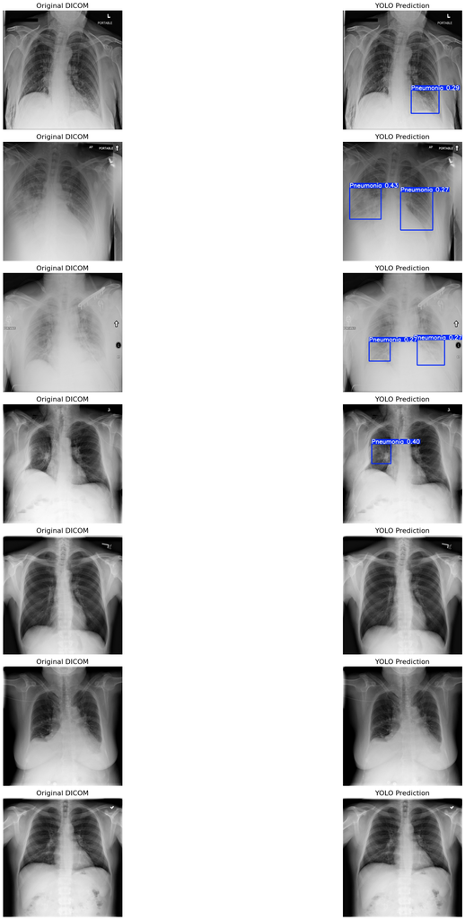

```python
import os
from PIL import Image
import matplotlib.pyplot as plt
import pydicom
import cv2
from random import sample
import zipfile
from io import BytesIO
import numpy as np

# Paths
results_dir = '/content/drive/MyDrive/yolov5_pneumonia/results/pneumonia_detection'
original_dicom_path = '/content/drive/MyDrive/Great Learning/AIML/Capstone Project/Project/stage_2_train_images.zip'

# List of result images
result_images = [f for f in os.listdir(results_dir) if f.endswith('.jpg')]
print(f"Total result images available: {len(result_images)}")

archive = zipfile.ZipFile(original_dicom_path, 'r')

images_to_show = []

# Filter images that have bounding boxes
for result_img_name in result_images:
    result_img_path = os.path.join(results_dir, result_img_name)
    result_img = Image.open(result_img_path).convert("RGB")
    result_array = np.array(result_img)

    # Check if the image has any non-white pixels (bounding box present)
    if np.any(result_array != 255):
        images_to_show.append(result_img_name)

print(f"Images with bounding boxes: {len(images_to_show)}")

# Sample up to 15 images with bounding boxes
num_samples = min(7, len(images_to_show))
sample_results = sample(images_to_show, num_samples)

# Increase figure size for better visibility
plt.figure(figsize=(30, 30))

for i, result_img_name in enumerate(sample_results):
    result_img_path = os.path.join(results_dir, result_img_name)
    result_img = Image.open(result_img_path).convert("RGB")

    # Extract patientId from result image filename
    patient_id = result_img_name.split('.')[0]  # Assuming filename format: 'UUID.jpg'
    file_path_in_zip = f'stage_2_train_images/{patient_id}.dcm'

    try:
        with archive.open(file_path_in_zip) as file:
            dicom_data = pydicom.dcmread(BytesIO(file.read()))
            img_array = dicom_data.pixel_array
            img_array = (img_array - img_array.min()) / (img_array.max() - img_array.min()) * 255.0
            img_array = cv2.convertScaleAbs(img_array)
            img_array = cv2.resize(img_array, (800, 800))  # Larger size for visibility
    except Exception as e:
        print(f"Original DICOM not found or corrupted for {patient_id}: {e}")
        continue

    # Plot Original DICOM image
    plt.subplot(num_samples, 2, i * 2 + 1)
    plt.imshow(img_array, cmap='gray')
    plt.axis('off')
    plt.title('Original DICOM', fontsize=16)

    # Plot YOLO detection result
    plt.subplot(num_samples, 2, i * 2 + 2)
    plt.imshow(result_img.resize((800, 800)))  # Resize result image for consistency
    plt.axis('off')
    plt.title('YOLO Prediction', fontsize=16)

plt.tight_layout()
plt.show()
```

#### **YOLO Detection Results Summary**

| Image # | Detection | # of Boxes | Confidence Scores | Observation |
| --- | --- | --- | --- | --- |
| 1 | Positive | 1 | 0.29 | Weak detection in right lower lung |
| 2 | Positive | 2 | 0.43, 0.27 | Stronger detection in left mid-lung, weak in right lower lung |
| 3 | Positive | 2 | 0.27, 0.27 | Bilateral detections but both low confidence |
| 4 | Positive | 1 | 0.40 | Moderate detection in left lower lung |
| 5 | Negative | 0 | – | No pneumonia detected (possible false negative) |
| 6 | Negative | 0 | – | No pneumonia detected (possible false negative) |
| 7 | Negative | 0 | – | No pneumonia detected (likely normal lungs) |

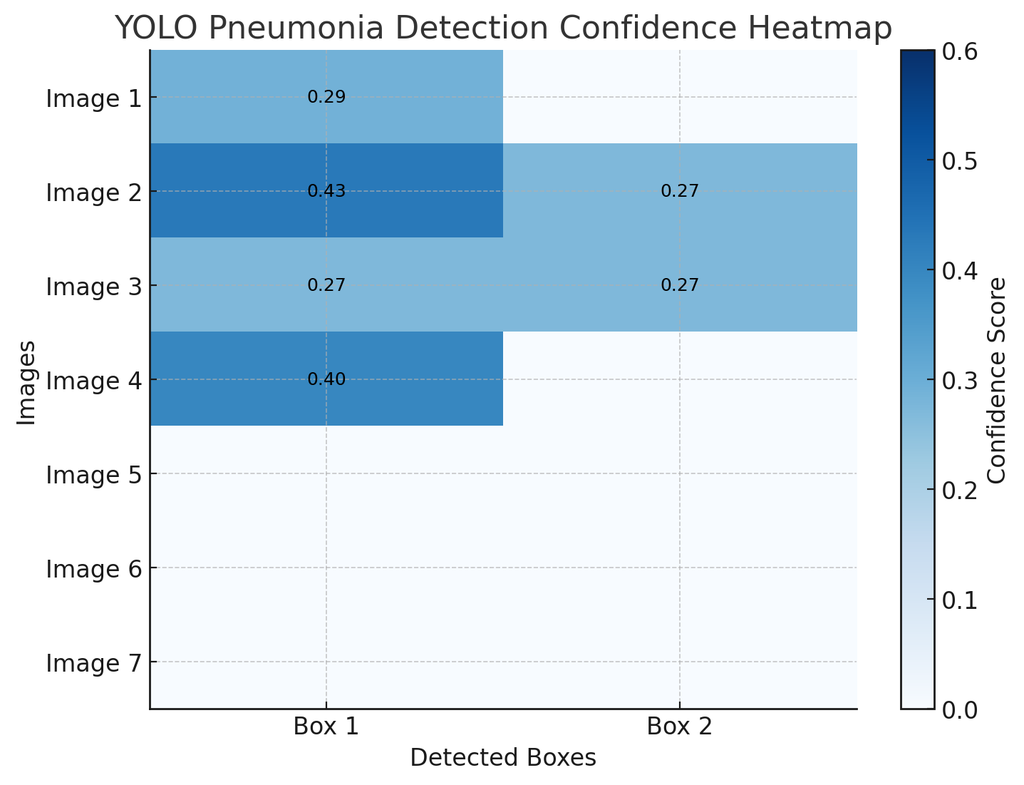

#### **Observations & Insights**

The YOLO model shows potential in localizing pneumonia regions, but current confidence scores are relatively low. It may need additional training data, higher-quality annotations, or threshold adjustments for clinical reliability.

### **Step 4: Pickle the model for future predictions**

```python
import torch
import pickle

# -----------------------------
# Save weights into a pickle file
# -----------------------------
weights_dict = {"state_dict": yolo_model.state_dict()}
pkl_path = "/content/drive/MyDrive/yolov5_pneumonia/yolov5_pneumonia.pkl"

with open(pkl_path, "wb") as f:
    pickle.dump(weights_dict, f)

print(f"✅ Pickle file created successfully at: {pkl_path}")
```

```
✅ Pickle file created successfully at: /content/drive/MyDrive/yolov5_pneumonia/yolov5_pneumonia.pkl
```

**Reload the pickled model**

```python
# -----------------------------
# Reload the model from pickle
# -----------------------------

# Path to your cloned YOLOv5 repo
repo_dir = '/content/yolov5'  # make sure you cloned YOLOv5 here

# Load pickled weights
with open(pkl_path, "rb") as f:
    checkpoint = pickle.load(f)

# Recreate YOLOv5 architecture (must match training)
yolo_model_reload = torch.hub.load(repo_dir, 'custom',
                                   path='/content/drive/MyDrive/yolov5_pneumonia/exp_pneumonia/weights/best.pt',
                                   source='local')

# Load saved weights
yolo_model_reload.load_state_dict(checkpoint["state_dict"])
yolo_model_reload.eval()

print("✅ YOLOv5 model reloaded successfully from pickle!")
```

```
YOLOv5 🚀 2025-9-21 Python-3.12.11 torch-2.8.0+cu126 CUDA:0 (Tesla T4, 15095MiB)

Fusing layers...
Model summary: 157 layers, 7012822 parameters, 0 gradients, 15.8 GFLOPs
Adding AutoShape...
```

```
✅ YOLOv5 model reloaded successfully from pickle!
```

## **Conclusion**

The objective of this project was to develop an automated system for detecting pneumonia in chest radiographs by identifying and localizing lung opacities. This task was approached as a classic computer vision problem, combining both image classification and object detection.

Through a series of experiments, several deep learning models were evaluated, including a Base CNN, Fine-Tuned CNN, DenseNet121, MobileNetV2, and ResNet50. The performance of these models revealed distinct strengths and weaknesses:

- **DenseNet121** emerged as the top performer, achieving the highest recall (0.47) and F1-score (0.53). Its strong performance in detecting positive pneumonia cases makes it the most suitable model for a clinical setting where missing a diagnosis could have severe consequences.
- **MobileNetV2** also performed well, excelling in precision (0.71) and ROC AUC (0.83). While it was more effective at avoiding false alarms, its lower recall (0.27) makes it less ideal as a primary diagnostic tool on its own.
- **The simple Basic CNN** provided a surprisingly strong baseline, performing nearly as well as the more complex DenseNet121 in several key metrics. This highlights the value of starting with a robust baseline before moving to more complex architectures.
- The **YOLOv5 model** was specifically evaluated for its localization capabilities. While it successfully detected pneumonia opacities in some images (4 out of 7), its performance was hampered by low confidence scores and missed detections. This indicates that while the model shows promise for localization, it is not yet clinically reliable and requires further refinement.

The project demonstrates that deep learning can be a powerful tool for assisting radiologists in pneumonia diagnosis. However, no single model is perfect, and a trade-off exists between a model's sensitivity (recall) and specificity (precision).

The final recommendation is a hybrid approach:

- **Deployment Model:** Use the **DenseNet121 model** as the primary classifier for initial screening due to its high recall, which minimizes the risk of missing a pneumonia case.
- **Model Ensemble:** For enhanced reliability, explore an ensemble strategy combining the high-recall DenseNet121 with the high-precision MobileNetV2. This approach has the potential to balance sensitivity and specificity, leading to a more robust and clinically trustworthy system.
- **Localization Enhancement:** The YOLOv5 model for bounding box localization requires further optimization. Future work should focus on providing more training data, improving annotation quality, and fine-tuning its hyperparameters to increase confidence scores and reduce false negatives.

In conclusion, this project provides a solid foundation for an automated pneumonia detection system. While the models show significant promise, continuous improvement through model refinement, external validation, and integration of both classification and localization components will be essential for creating a system that can truly assist and empower medical professionals.